# Project: Identify Customer Segments

```python
# import libraries here; add more as necessary
import numpy as np
import pandas as pd
import matplotlib.pyplot as plt
import seaborn as sns

# magic word for producing visualizations in notebook
%matplotlib inline
```

### Datasets

Each row of the demographics files represents a single person, but also includes information outside of individuals, including information about their household, building, and neighborhood. I used this information to cluster the general population into groups with similar demographic properties.

```python
# Load in the general demographics data.
azdias = pd.read_csv('Udacity_AZDIAS_Subset.csv')

# Load in the feature summary file.
feat_info = pd.read_csv('AZDIAS_Feature_Summary.csv')
```

```python
azdias = azdias.loc[:, ~azdias.columns.str.contains('^Unnamed')]
```

```python
feat_info = feat_info.loc[:, ~feat_info.columns.str.contains('^Unnamed')]
```

```python
# Check the structure of the data after it's loaded (e.g. print the number of
# rows and columns, print the first few rows).

azdias.describe()
```

|  | AGER_TYP | ALTERSKATEGORIE_GROB | ANREDE_KZ | CJT_GESAMTTYP | FINANZ_MINIMALIST | FINANZ_SPARER | FINANZ_VORSORGER | FINANZ_ANLEGER | FINANZ_UNAUFFAELLIGER | FINANZ_HAUSBAUER | ... | PLZ8_ANTG1 | PLZ8_ANTG2 | PLZ8_ANTG3 | PLZ8_ANTG4 | PLZ8_BAUMAX | PLZ8_HHZ | PLZ8_GBZ | ARBEIT | ORTSGR_KLS9 | RELAT_AB |
| --- | --- | --- | --- | --- | --- | --- | --- | --- | --- | --- | --- | --- | --- | --- | --- | --- | --- | --- | --- | --- | --- |
| count | 891221.000000 | 891221.000000 | 891221.000000 | 886367.000000 | 891221.000000 | 891221.000000 | 891221.000000 | 891221.000000 | 891221.000000 | 891221.000000 | ... | 774706.000000 | 774706.000000 | 774706.000000 | 774706.000000 | 774706.000000 | 774706.000000 | 774706.000000 | 794005.000000 | 794005.000000 | 794005.00000 |
| mean | -0.358435 | 2.777398 | 1.522098 | 3.632838 | 3.074528 | 2.821039 | 3.401106 | 3.033328 | 2.874167 | 3.075121 | ... | 2.253330 | 2.801858 | 1.595426 | 0.699166 | 1.943913 | 3.612821 | 3.381087 | 3.167854 | 5.293002 | 3.07222 |
| std | 1.198724 | 1.068775 | 0.499512 | 1.595021 | 1.321055 | 1.464749 | 1.322134 | 1.529603 | 1.486731 | 1.353248 | ... | 0.972008 | 0.920309 | 0.986736 | 0.727137 | 1.459654 | 0.973967 | 1.111598 | 1.002376 | 2.303739 | 1.36298 |
| min | -1.000000 | 1.000000 | 1.000000 | 1.000000 | 1.000000 | 1.000000 | 1.000000 | 1.000000 | 1.000000 | 1.000000 | ... | 0.000000 | 0.000000 | 0.000000 | 0.000000 | 1.000000 | 1.000000 | 1.000000 | 1.000000 | 0.000000 | 1.00000 |
| 25% | -1.000000 | 2.000000 | 1.000000 | 2.000000 | 2.000000 | 1.000000 | 3.000000 | 2.000000 | 2.000000 | 2.000000 | ... | 1.000000 | 2.000000 | 1.000000 | 0.000000 | 1.000000 | 3.000000 | 3.000000 | 3.000000 | 4.000000 | 2.00000 |
| 50% | -1.000000 | 3.000000 | 2.000000 | 4.000000 | 3.000000 | 3.000000 | 3.000000 | 3.000000 | 3.000000 | 3.000000 | ... | 2.000000 | 3.000000 | 2.000000 | 1.000000 | 1.000000 | 4.000000 | 3.000000 | 3.000000 | 5.000000 | 3.00000 |
| 75% | -1.000000 | 4.000000 | 2.000000 | 5.000000 | 4.000000 | 4.000000 | 5.000000 | 5.000000 | 4.000000 | 4.000000 | ... | 3.000000 | 3.000000 | 2.000000 | 1.000000 | 3.000000 | 4.000000 | 4.000000 | 4.000000 | 7.000000 | 4.00000 |
| max | 3.000000 | 9.000000 | 2.000000 | 6.000000 | 5.000000 | 5.000000 | 5.000000 | 5.000000 | 5.000000 | 5.000000 | ... | 4.000000 | 4.000000 | 3.000000 | 2.000000 | 5.000000 | 5.000000 | 5.000000 | 9.000000 | 9.000000 | 9.00000 |

8 rows × 81 columns

```python
azdias.head()
```

|  | AGER_TYP | ALTERSKATEGORIE_GROB | ANREDE_KZ | CJT_GESAMTTYP | FINANZ_MINIMALIST | FINANZ_SPARER | FINANZ_VORSORGER | FINANZ_ANLEGER | FINANZ_UNAUFFAELLIGER | FINANZ_HAUSBAUER | ... | PLZ8_ANTG1 | PLZ8_ANTG2 | PLZ8_ANTG3 | PLZ8_ANTG4 | PLZ8_BAUMAX | PLZ8_HHZ | PLZ8_GBZ | ARBEIT | ORTSGR_KLS9 | RELAT_AB |
| --- | --- | --- | --- | --- | --- | --- | --- | --- | --- | --- | --- | --- | --- | --- | --- | --- | --- | --- | --- | --- | --- |
| 0 | -1 | 2 | 1 | 2.0 | 3 | 4 | 3 | 5 | 5 | 3 | ... | NaN | NaN | NaN | NaN | NaN | NaN | NaN | NaN | NaN | NaN |
| 1 | -1 | 1 | 2 | 5.0 | 1 | 5 | 2 | 5 | 4 | 5 | ... | 2.0 | 3.0 | 2.0 | 1.0 | 1.0 | 5.0 | 4.0 | 3.0 | 5.0 | 4.0 |
| 2 | -1 | 3 | 2 | 3.0 | 1 | 4 | 1 | 2 | 3 | 5 | ... | 3.0 | 3.0 | 1.0 | 0.0 | 1.0 | 4.0 | 4.0 | 3.0 | 5.0 | 2.0 |
| 3 | 2 | 4 | 2 | 2.0 | 4 | 2 | 5 | 2 | 1 | 2 | ... | 2.0 | 2.0 | 2.0 | 0.0 | 1.0 | 3.0 | 4.0 | 2.0 | 3.0 | 3.0 |
| 4 | -1 | 3 | 1 | 5.0 | 4 | 3 | 4 | 1 | 3 | 2 | ... | 2.0 | 4.0 | 2.0 | 1.0 | 2.0 | 3.0 | 3.0 | 4.0 | 6.0 | 5.0 |

5 rows × 85 columns

```python
azdias.shape
```

```
(891221, 85)
```

```python
print('features')

feat_info.describe()
```

```
features
```

|  | attribute | information_level | type | missing_or_unknown |
| --- | --- | --- | --- | --- |
| count | 85 | 85 | 85 | 85 |
| unique | 85 | 9 | 5 | 9 |
| top | ANZ_PERSONEN | person | ordinal | [-1] |
| freq | 1 | 43 | 49 | 26 |

```python
feat_info.head()
```

|  | attribute | information_level | type | missing_or_unknown |
| --- | --- | --- | --- | --- |
| 0 | AGER_TYP | person | categorical | [-1,0] |
| 1 | ALTERSKATEGORIE_GROB | person | ordinal | [-1,0,9] |
| 2 | ANREDE_KZ | person | categorical | [-1,0] |
| 3 | CJT_GESAMTTYP | person | categorical | [0] |
| 4 | FINANZ_MINIMALIST | person | ordinal | [-1] |

```python
feat_info.shape
```

```
(85, 4)
```

## Step 1: Preprocessing

### Step 1.1: Assessing Missing Data by Converting Missing Value Codes to NaNs

I started the process of data preparation by converting the missing value codes to NaNs in the actual dataset. The codes for missing or unknown values were obtained from the document of detailed information on the features. After converting all the missing or unknown values in the dataset to NaN, I wanted to work on identifying the pattern of missing values in the dataset. First, I wanted to find how much missing data is present in each column, so I worked on finding the outliers columns, which are columns that are in different proportions in terms of values that are missing.

```python
# Identify missing or unknown data values and convert them to NaNs.

#Get stat of missing data
azdias.isnull().sum()
```

```
AGER_TYP                     0
ALTERSKATEGORIE_GROB         0
ANREDE_KZ                    0
CJT_GESAMTTYP             4854
FINANZ_MINIMALIST            0
                         ...
PLZ8_HHZ                116515
PLZ8_GBZ                116515
ARBEIT                   97216
ORTSGR_KLS9              97216
RELAT_AB                 97216
Length: 85, dtype: int64
```

```python
# creating a list of dataframe columns
feature_list = feat_info[['attribute', 'missing_or_unknown']]
```

```python
feature_list
```

|  | attribute | missing_or_unknown |
| --- | --- | --- |
| 0 | AGER_TYP | [-1,0] |
| 1 | ALTERSKATEGORIE_GROB | [-1,0,9] |
| 2 | ANREDE_KZ | [-1,0] |
| 3 | CJT_GESAMTTYP | [0] |
| 4 | FINANZ_MINIMALIST | [-1] |
| ... | ... | ... |
| 80 | PLZ8_HHZ | [-1] |
| 81 | PLZ8_GBZ | [-1] |
| 82 | ARBEIT | [-1,9] |
| 83 | ORTSGR_KLS9 | [-1,0] |
| 84 | RELAT_AB | [-1,9] |

85 rows × 2 columns

```python
#Parse stringified list back to a list

parsed_feature_dict = {}
import json
for item in feature_list.values:
    res = item[1].strip("][").split(",")
    parsed_feature_dict[item[0]] = res
```

```python
parsed_feature_dict['AGER_TYP']
```

```
['-1', '0']
```

```python
# Convert data that matches a 'missing' or 'unknown' value code into a numpy NaN value.
# Convert data that matches a 'missing' or 'unknown' value code into a numpy NaN value.
for column in azdias.columns:
    for item in parsed_feature_dict[column]:
        if(item == ''):
            continue
        if azdias[column].dtype == 'object':

            azdias.loc[azdias[column] == item,column] = np.nan
        else:
            azdias.loc[azdias[column] == int(item),column] = np.nan
```

```python
azdias.isnull().sum().sum()
```

```
8373929
```

```python
#Get stat of missing data after replacing with NaN
azdias.isnull().sum()
```

```
AGER_TYP                685843
ALTERSKATEGORIE_GROB      2881
ANREDE_KZ                    0
CJT_GESAMTTYP             4854
FINANZ_MINIMALIST            0
                         ...
PLZ8_HHZ                116515
PLZ8_GBZ                116515
ARBEIT                   97375
ORTSGR_KLS9              97274
RELAT_AB                 97375
Length: 85, dtype: int64
```

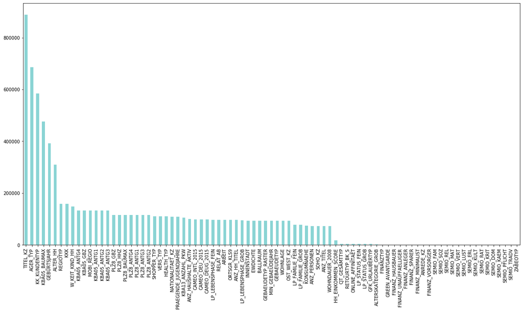

```python
# Perform an assessment of how much missing data there is in each column of the
# dataset.

azdias.isnull().sum().sort_values(ascending=False).plot.bar(figsize=(20,10), color='#8ad4d4')
```

# Investigate patterns in the amount of missing data in each column.

After visualizing the distribution of missing value, we can see that there are some features with missing data more than most of the attributes in the dataset. For this dataset, it seems that the outliers are the features that have above 200,000 missing data.

Based on the observation above, I made the decision of removing the following columns: ‘AGER_TYP’, ‘GEBURTSJAHR’, ‘TITEL_KZ’, ‘ALTER_HH’, ‘KK_KUNDENTYP’, and ‘KBA05_BAUMAX’, as they had above 200,000 missing data.

```python
azdias.shape[0] - azdias.count()
```

```
AGER_TYP                685843
ALTERSKATEGORIE_GROB      2881
ANREDE_KZ                    0
CJT_GESAMTTYP             4854
FINANZ_MINIMALIST            0
                         ...
PLZ8_HHZ                116515
PLZ8_GBZ                116515
ARBEIT                   97375
ORTSGR_KLS9              97274
RELAT_AB                 97375
Length: 85, dtype: int64
```

```python
outliers_list=[]
for col in azdias.columns:
    if(azdias[col].isnull().sum() > 200000):
        outliers_list.append(col)
print(outliers_list)
```

```
['AGER_TYP', 'GEBURTSJAHR', 'TITEL_KZ', 'ALTER_HH', 'KK_KUNDENTYP', 'KBA05_BAUMAX']
```

```python
#invistigating the features that were predicted to be outliers
```

```python
azdias['AGER_TYP'].describe()
```

```
count    205378.000000
mean          1.743410
std           0.674312
min           1.000000
25%           1.000000
50%           2.000000
75%           2.000000
max           3.000000
Name: AGER_TYP, dtype: float64
```

```python
azdias['GEBURTSJAHR'].describe()
```

```
count    498903.000000
mean       1967.102689
std          17.795208
min        1900.000000
25%        1955.000000
50%        1968.000000
75%        1981.000000
max        2017.000000
Name: GEBURTSJAHR, dtype: float64
```

```python
azdias['TITEL_KZ'].describe()
```

```
count    2160.000000
mean        1.318519
std         0.999504
min         1.000000
25%         1.000000
50%         1.000000
75%         1.000000
max         5.000000
Name: TITEL_KZ, dtype: float64
```

```python
azdias['ALTER_HH'].describe()
```

```
count    580954.000000
mean         15.291805
std           3.800536
min           1.000000
25%          13.000000
50%          16.000000
75%          18.000000
max          21.000000
Name: ALTER_HH, dtype: float64
```

```python
azdias['KK_KUNDENTYP'].describe()
```

```
count    306609.000000
mean          3.410640
std           1.628844
min           1.000000
25%           2.000000
50%           3.000000
75%           5.000000
max           6.000000
Name: KK_KUNDENTYP, dtype: float64
```

```python
azdias['KBA05_BAUMAX'].describe()
```

```
count    414697.000000
mean          2.539534
std           1.693151
min           1.000000
25%           1.000000
50%           1.000000
75%           4.000000
max           5.000000
Name: KBA05_BAUMAX, dtype: float64
```

```python
azdias.info()
```

```
<class 'pandas.core.frame.DataFrame'>
RangeIndex: 891221 entries, 0 to 891220
Data columns (total 85 columns):
AGER_TYP                 205378 non-null float64
ALTERSKATEGORIE_GROB     888340 non-null float64
ANREDE_KZ                891221 non-null float64
CJT_GESAMTTYP            886367 non-null float64
FINANZ_MINIMALIST        891221 non-null float64
FINANZ_SPARER            891221 non-null float64
FINANZ_VORSORGER         891221 non-null float64
FINANZ_ANLEGER           891221 non-null float64
FINANZ_UNAUFFAELLIGER    891221 non-null float64
FINANZ_HAUSBAUER         891221 non-null float64
FINANZTYP                891221 non-null float64
GEBURTSJAHR              498903 non-null float64
GFK_URLAUBERTYP          886367 non-null float64
GREEN_AVANTGARDE         891221 non-null int64
HEALTH_TYP               780025 non-null float64
LP_LEBENSPHASE_FEIN      793589 non-null float64
LP_LEBENSPHASE_GROB      796649 non-null float64
LP_FAMILIE_FEIN          813429 non-null float64
LP_FAMILIE_GROB          813429 non-null float64
LP_STATUS_FEIN           886367 non-null float64
LP_STATUS_GROB           886367 non-null float64
NATIONALITAET_KZ         782906 non-null float64
PRAEGENDE_JUGENDJAHRE    783057 non-null float64
RETOURTYP_BK_S           886367 non-null float64
SEMIO_SOZ                891221 non-null float64
SEMIO_FAM                891221 non-null float64
SEMIO_REL                891221 non-null float64
SEMIO_MAT                891221 non-null float64
SEMIO_VERT               891221 non-null float64
SEMIO_LUST               891221 non-null float64
SEMIO_ERL                891221 non-null float64
SEMIO_KULT               891221 non-null float64
SEMIO_RAT                891221 non-null float64
SEMIO_KRIT               891221 non-null float64
SEMIO_DOM                891221 non-null float64
SEMIO_KAEM               891221 non-null float64
SEMIO_PFLICHT            891221 non-null float64
```

[output cut: 35 more lines]

```
ONLINE_AFFINITAET        886367 non-null float64
REGIOTYP                 733157 non-null float64
KBA13_ANZAHL_PKW         785421 non-null float64
PLZ8_ANTG1               774706 non-null float64
PLZ8_ANTG2               774706 non-null float64
PLZ8_ANTG3               774706 non-null float64
PLZ8_ANTG4               774706 non-null float64
PLZ8_BAUMAX              774706 non-null float64
PLZ8_HHZ                 774706 non-null float64
PLZ8_GBZ                 774706 non-null float64
ARBEIT                   793846 non-null float64
ORTSGR_KLS9              793947 non-null float64
RELAT_AB                 793846 non-null float64
dtypes: float64(80), int64(1), object(4)
memory usage: 578.0+ MB
```

```python
# Remove the outlier columns from the dataset. (You'll perform other data
# engineering tasks such as re-encoding and imputation later.)

#Columns to be dropped
print(outliers_list)
```

```
['AGER_TYP', 'GEBURTSJAHR', 'TITEL_KZ', 'ALTER_HH', 'KK_KUNDENTYP', 'KBA05_BAUMAX']
```

```python
#Any attribute in outliers_list will be dropped from the dataset
azdias.drop(outliers_list,axis = 1, inplace = True)

#Dropping outliers from feat_info as well
feat_info = feat_info[~feat_info.attribute.isin(outliers_list)]
```

```python
azdias.shape
```

```
(891221, 79)
```

```python
feat_info.shape
```

```
(79, 4)
```

### Step 1.2: Assess Missing Data in Each Row

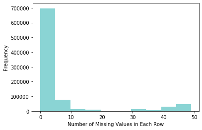

```python
# How much data is missing in each row of the dataset?
azdias.isnull().sum(axis=1).sort_values(ascending=False).plot(kind='hist', color='#8ad4d4')
plt.xlabel('Number of Missing Values in Each Row')
```

After visualizing the distribution of missing values in each row, I found the number of rows with many missing values to be 93,154 or 10.45 % of all data, I sat the threshold to be 30. After dividing the data into two subsets, one for data points that are above 30 missing values, and a second subset for points below the threshold, I decided to visualize the distributions of non-missing features between the data with many missing values and the data with few or no missing values. I selected 5 columns to plot the comparison.

```python
# Write code to divide the data into two subsets based on the number of missing
# values in each row.

#Subset 1 with missing vlaues above 30
azdias_above_mean=azdias[azdias.isnull().sum(axis=1) > 30]
#Subset 2 with missing vlaues above 30
azdias_below_mean=azdias[azdias.isnull().sum(axis=1) <= 30]

print('Summary of Missing Data:\nthe number of rows with many missing values: ', azdias_above_mean.shape[0], 'or', \
      np.round(azdias_above_mean.shape[0]*100/azdias.isnull().sum(axis=1).shape[0],2), '% of all data')
```

```
Summary of Missing Data:
the number of rows with many missing values:  93154 or 10.45 % of all data
```

```python
# Compare the distribution of values for at least five columns where there are
# no or few missing values, between the two subsets.

azdias_above_mean.iloc[:,:5].count()
```

```
ALTERSKATEGORIE_GROB    93076
ANREDE_KZ               93154
CJT_GESAMTTYP           93049
FINANZ_MINIMALIST       93154
FINANZ_SPARER           93154
dtype: int64
```

```python
azdias_below_mean.iloc[:,:5].count()
```

```
ALTERSKATEGORIE_GROB    795264
ANREDE_KZ               798067
CJT_GESAMTTYP           793318
FINANZ_MINIMALIST       798067
FINANZ_SPARER           798067
dtype: int64
```

```python
def comparison_plot(column):
    fig = plt.figure(figsize=(14,4))
    ax1 = fig.add_subplot(121)
    ax1.title.set_text('With Many Missing Rows')
    sns.countplot(azdias.loc[azdias_above_mean.index,column], palette="Set3")

    ax2 = fig.add_subplot(122)
    ax2.title.set_text('With Few or No Missing Values')
    sns.countplot(azdias.loc[azdias_below_mean.index,column], palette="Set3")


    fig.suptitle(column)
    plt.show()
```

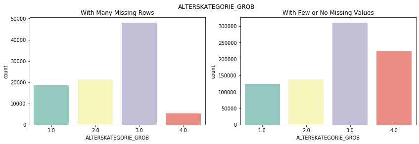

```python
comparison_plot('ALTERSKATEGORIE_GROB')
```

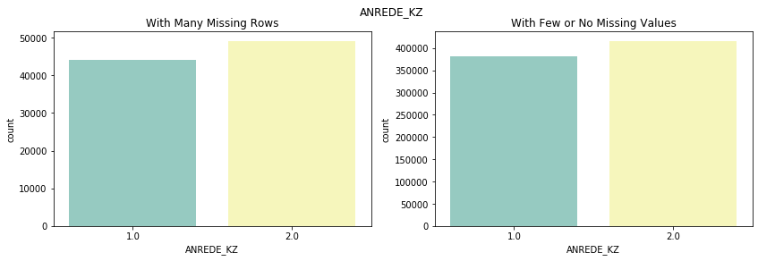

```python
comparison_plot('ANREDE_KZ')
```

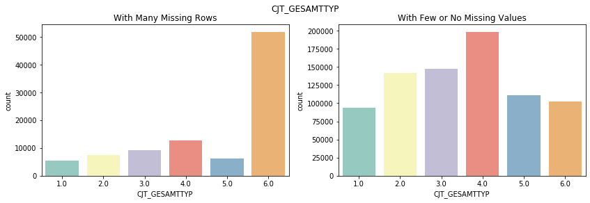

```python
comparison_plot('CJT_GESAMTTYP')
```

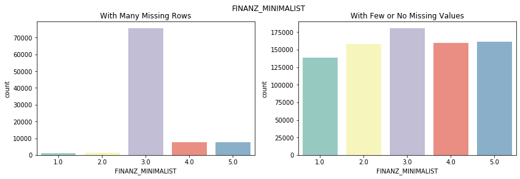

```python
comparison_plot('FINANZ_MINIMALIST')
```

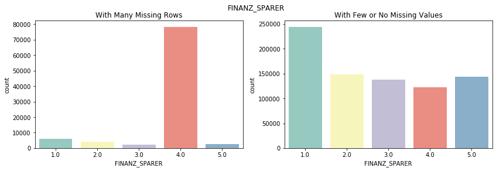

```python
comparison_plot('FINANZ_SPARER')
```

From the graphs of distributions above, we can conclude that the distribution of data with many missing values is very different from data with few or no missing values, meaning that the data should be kept for now.

### Step 1.2: Select and Re-Encode Features

```python
# How many features are there of each data type?

type_dict={}

for ind in feat_info.index:
    row_type = feat_info['type'][ind]
    if row_type not in type_dict.keys():
        type_dict[row_type] = 1
    else:
        type_dict[row_type] += 1

print(type_dict)
```

```
{'ordinal': 49, 'categorical': 18, 'mixed': 6, 'numeric': 6}
```

#### Step 1.2.1: Re-Encode Categorical Features

```python
# Assess categorical variables: which are binary, which are multi-level, and
# which one needs to be re-encoded?


#Get a list of columns with categorial datatypes

categorical_attribute = feat_info[feat_info.type == 'categorical'].attribute
print(categorical_attribute)
```

```
2            ANREDE_KZ
3        CJT_GESAMTTYP
10           FINANZTYP
12     GFK_URLAUBERTYP
13    GREEN_AVANTGARDE
17     LP_FAMILIE_FEIN
18     LP_FAMILIE_GROB
19      LP_STATUS_FEIN
20      LP_STATUS_GROB
21    NATIONALITAET_KZ
38         SHOPPER_TYP
39             SOHO_KZ
41            VERS_TYP
42            ZABEOTYP
52         GEBAEUDETYP
55         OST_WEST_KZ
57     CAMEO_DEUG_2015
58      CAMEO_DEU_2015
Name: attribute, dtype: object
```

```python
azdias.shape
```

```
(891221, 79)
```

```python
# Re-encode categorical variable(s) to be kept in the analysis.

#Returns two lists: binary categorical list and multilevel categorical list
def get_cat(azdias, categorical_attribute):
    binary_features = []
    multi_features = []
    for item in categorical_attribute:
        if azdias[item].nunique() == 2:
            binary_features.append(item)
        elif azdias[item].nunique() > 2:
            multi_features.append(item)
    print('Binary Categorical Features')
    print(binary_features)
    print('Count: ', len(binary_features))
    print('Multi Categorical Features')
    print(multi_features)
    print('Count: ', len(multi_features))
    return binary_features, multi_features

binary_cat, multi_cat = get_cat(azdias, categorical_attribute)
```

```
Binary Categorical Features
['ANREDE_KZ', 'GREEN_AVANTGARDE', 'SOHO_KZ', 'VERS_TYP', 'OST_WEST_KZ']
Count:  5
Multi Categorical Features
['CJT_GESAMTTYP', 'FINANZTYP', 'GFK_URLAUBERTYP', 'LP_FAMILIE_FEIN', 'LP_FAMILIE_GROB', 'LP_STATUS_FEIN', 'LP_STATUS_GROB', 'NATIONALITAET_KZ', 'SHOPPER_TYP', 'ZABEOTYP', 'GEBAEUDETYP', 'CAMEO_DEUG_2015', 'CAMEO_DEU_2015']
Count:  13
```

```python
#binary cat features re-encoding
#find binary with non-numeric value
for col in binary_cat:
    if azdias[col].dtypes == object:
        print(azdias[col].value_counts())

#re-encoding non-numerical values
azdias['OST_WEST_KZ'] = azdias['OST_WEST_KZ'].replace('W', 1)
azdias['OST_WEST_KZ'] = azdias['OST_WEST_KZ'].replace('O', 0)
print(azdias['OST_WEST_KZ'].value_counts())
```

```
W    629528
O    168545
Name: OST_WEST_KZ, dtype: int64
1.0    629528
0.0    168545
Name: OST_WEST_KZ, dtype: int64
```

```python
#Multilevel features will be dropped

for col in multi_cat:
    azdias.drop(columns = col, inplace=True)
```

```python
azdias.shape
```

```
(891221, 66)
```

#### Discussion 1.2.1: Re-Encode Categorical Features

For binary categoricals, I found OST_WEST_KZ to have non-numerical values, so I encoded these values to be numbers by replacing 'W' with 1 and 'O' with 0. Multi-level categoricals were dropped from the dataset.

#### Step 1.2.2: Engineer Mixed-Type Features

```python
#Finding mixed features
mixed_features = feat_info[feat_info.type == 'mixed'].attribute
print(mixed_features)
```

```
15      LP_LEBENSPHASE_FEIN
16      LP_LEBENSPHASE_GROB
22    PRAEGENDE_JUGENDJAHRE
56                 WOHNLAGE
59          CAMEO_INTL_2015
79              PLZ8_BAUMAX
Name: attribute, dtype: object
```

```python
# Investigate "PRAEGENDE_JUGENDJAHRE" and engineer two new variables.

# Create an interval-type variable for decade
decade = {0: [1, 2],
            1: [3, 4],
            2: [5, 6, 7],
            3: [8, 9],
            4: [10, 11, 12, 13],
            5: [14, 15]}

def map_decade(item):
    try:
        for key, value in decade.items():
            if item in value:
                return key
    except ValueError:
        return np.nan

#Creating binary variable for movement
mainstream = [1, 3, 5, 8, 10, 12, 14]

def map_movement(item):
    try:
        if item in mainstream:
            return 0
        else:
            return 1
    except ValueError:
        return np.nan

# Create generation column
azdias['PRAEGENDE_JUGENDJAHRE_decade'] = azdias['PRAEGENDE_JUGENDJAHRE'].apply(map_decade)

# Create movement column
azdias['PRAEGENDE_JUGENDJAHRE_movement'] = azdias['PRAEGENDE_JUGENDJAHRE'].apply(map_movement)
```

```python
# Investigate "CAMEO_INTL_2015" and engineer two new variables.

#Break up the two-digit codes by their 'tens'-place and 'ones'-place digits into two new ordinal variables
#which, for the purposes of this project, is equivalent to just treating them as their raw numeric values

# Map wealth
def map_wealth(item):
    if pd.isnull(item):
        return np.nan
    else:
        return int(str(item)[0])

# Map life stage
def map_lifestage(item):
    if pd.isnull(item):
        return np.nan
    else:
        return int(str(item)[1])

# Create wealth column
azdias['CAMEO_INTL_2015_wealth'] = azdias['CAMEO_INTL_2015'].apply(map_wealth)

# Create life stage column
azdias['CAMEO_INTL_2015_lifestage'] = azdias['CAMEO_INTL_2015'].apply(map_lifestage)
```

```python
# Drop PRAEGENDE_JUGENDJAHRE and CAMEO_INTL_2015 in addition to the rest of mixed features since we will not be using them
for col in mixed_features:
    azdias.drop(columns = col, inplace=True)
#azdias = azdias.drop(['PRAEGENDE_JUGENDJAHRE', 'CAMEO_INTL_2015'], axis=1)
```

```python
azdias.shape
```

```
(891221, 64)
```

#### Discussion 1.2.2: Engineer Mixed-Type Features

For CAMEO_INTL_2015, I created a two new variabls and replaced CAMEO_INTL_2015 with them. For PRAEGENDE_JUGENDJAHRE, I created a dictionary for decades that maps decades with their values, and a dictionary for movement as well, the discitonaries were used to construct the new variables. Afterwards, all the mixed values were dropped.

### Step 1.3: Create a Cleaning Function

```python
def clean_data(df):
    """
    Perform feature trimming, re-encoding, and engineering for demographics
    data

    INPUT: Demographics DataFrame
    OUTPUT: Trimmed and cleaned demographics DataFrame
    """
    azdias = df
    # Put in code here to execute all main cleaning steps:
    # convert missing value codes into NaNs, ...

    feat_info = pd.read_csv('AZDIAS_Feature_Summary.csv')
    azdias = azdias.loc[:, ~azdias.columns.str.contains('^Unnamed')]
    feature_list = feat_info[['attribute', 'missing_or_unknown']]
    parsed_feature_dict = {}
    import json
    for item in feature_list.values:
        res = item[1].strip("][").split(",")
        parsed_feature_dict[item[0]] = res

    for column in azdias.columns:
        for item in parsed_feature_dict[column]:
            if(item == ''):
                continue
            if azdias[column].dtype == 'object':
                azdias.loc[azdias[column] == item,column] = np.nan
            else:
                azdias.loc[azdias[column] == int(item),column] = np.nan

    # remove selected columns and rows, ...
    outliers_list=['AGER_TYP', 'GEBURTSJAHR', 'TITEL_KZ', 'ALTER_HH', 'KK_KUNDENTYP', 'KBA05_BAUMAX'] #['AGER_TYP', 'TITEL_KZ', 'KK_KUNDENTYP', 'KBA05_BAUMAX']

    #Any attribute in outliers_list will be dropped from the dataset
    azdias.drop(outliers_list,axis = 1, inplace = True)

    #Dropping outliers from feat_info as well
    feat_info = feat_info[~feat_info.attribute.isin(outliers_list)]

    # select, re-encode, and engineer column values.
    type_dict={}

    for ind in feat_info.index:
        row_type = feat_info['type'][ind]
        if row_type not in type_dict.keys():
            type_dict[row_type] = 1
        else:
            type_dict[row_type] += 1

    #Get a list of columns with categorial datatypes

    categorical_attribute = feat_info[feat_info.type == 'categorical'].attribute

    binary_cat, multi_cat = get_cat(azdias, categorical_attribute)

    #binary cat features re-encoding
    #find binary with non-numeric value
    for col in binary_cat:
        if azdias[col].dtypes == object:
            print(azdias[col].value_counts())

    #re-encoding non-numerical values
    azdias['OST_WEST_KZ'] = azdias['OST_WEST_KZ'].replace('W', 1)
    azdias['OST_WEST_KZ'] = azdias['OST_WEST_KZ'].replace('O', 0)
    print(azdias['OST_WEST_KZ'].value_counts())

    #Multilevel features will be dropped

    for col in multi_cat:
        azdias.drop(columns = col, inplace=True)

    #Finding mixed features
    mixed_features = feat_info[feat_info.type == 'mixed'].attribute

    # Create generation column
    azdias['PRAEGENDE_JUGENDJAHRE_decade'] = azdias['PRAEGENDE_JUGENDJAHRE'].apply(map_decade)

    # Create movement column
    azdias['PRAEGENDE_JUGENDJAHRE_movement'] = azdias['PRAEGENDE_JUGENDJAHRE'].apply(map_movement)

    # Create wealth column
    azdias['CAMEO_INTL_2015_wealth'] = azdias['CAMEO_INTL_2015'].apply(map_wealth)

    # Create life stage column
    azdias['CAMEO_INTL_2015_lifestage'] = azdias['CAMEO_INTL_2015'].apply(map_lifestage)

    # Drop PRAEGENDE_JUGENDJAHRE and CAMEO_INTL_2015 in addition to the rest of mixed features since we will not be using them
    for col in mixed_features:
        azdias.drop(columns = col, inplace=True)

    # Return the cleaned dataframe.

    return azdias
```

```python
customers = pd.read_csv('Udacity_CUSTOMERS_Subset.csv')
customers_cleaning = clean_data(customers)
```

```
Binary Categorical Features
['ANREDE_KZ', 'GREEN_AVANTGARDE', 'SOHO_KZ', 'VERS_TYP', 'OST_WEST_KZ']
Count:  5
Multi Categorical Features
['CJT_GESAMTTYP', 'FINANZTYP', 'GFK_URLAUBERTYP', 'LP_FAMILIE_FEIN', 'LP_FAMILIE_GROB', 'LP_STATUS_FEIN', 'LP_STATUS_GROB', 'NATIONALITAET_KZ', 'SHOPPER_TYP', 'ZABEOTYP', 'GEBAEUDETYP', 'CAMEO_DEUG_2015', 'CAMEO_DEU_2015']
Count:  13
W    130382
O     11343
Name: OST_WEST_KZ, dtype: int64
1.0    130382
0.0     11343
Name: OST_WEST_KZ, dtype: int64
```

```python
customers = customers.loc[:, ~customers.columns.str.contains('^Unnamed')]
```

```python
azdias.shape, customers_cleaning.shape
```

```
((891221, 64), (191652, 64))
```

## Step 2: Feature Transformation

### Step 2.1: Apply Feature Scaling

```python
#Cleaning the dataset from NaNs
from sklearn.preprocessing import Imputer
from sklearn.preprocessing import StandardScaler
import numpy

features_set = azdias.copy()

imputer = Imputer(strategy='median')
imputed_values = imputer.fit_transform(features_set)
```

```python
# Apply feature scaling to the general population demographics data.

scaler = StandardScaler()
scaled_values = scaler.fit_transform(imputed_values)
```

### Discussion 2.1: Apply Feature Scaling

I used imputer to deal with NaN values by replacing them with the median value, and then applied scalar transformation to normalize all the values in the dataset.

### Step 2.2: Perform Dimensionality Reduction

```python
# Apply PCA to the data.
from sklearn.decomposition import PCA

pca = PCA()
pca_features = pca.fit_transform(scaled_values)
```

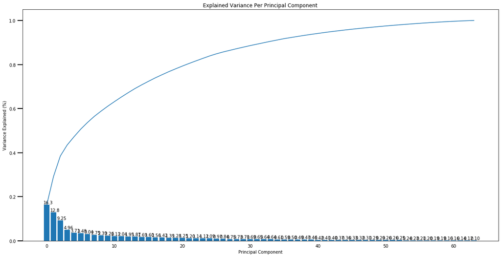

```python
# Investigate the variance accounted for by each principal component.

def scree_plot(pca):

    num_components = len(pca.explained_variance_ratio_)
    ind = np.arange(num_components)
    vals = pca.explained_variance_ratio_


    plt.figure(figsize=(20, 10))
    ax = plt.subplot(111)
    cumvals = np.cumsum(vals)
    ax.bar(ind, vals)
    ax.plot(ind, cumvals)
    for i in range(num_components):
        ax.annotate(((str(vals[i]*100)[:4])), (ind[i]+0.2, vals[i]), va="bottom", ha="center", fontsize=10)

    ax.xaxis.set_tick_params(width=0)
    ax.yaxis.set_tick_params(width=2, length=12)

    ax.set_xlabel("Principal Component")
    ax.set_ylabel("Variance Explained (%)")
    plt.title('Explained Variance Per Principal Component')


scree_plot(pca)
```

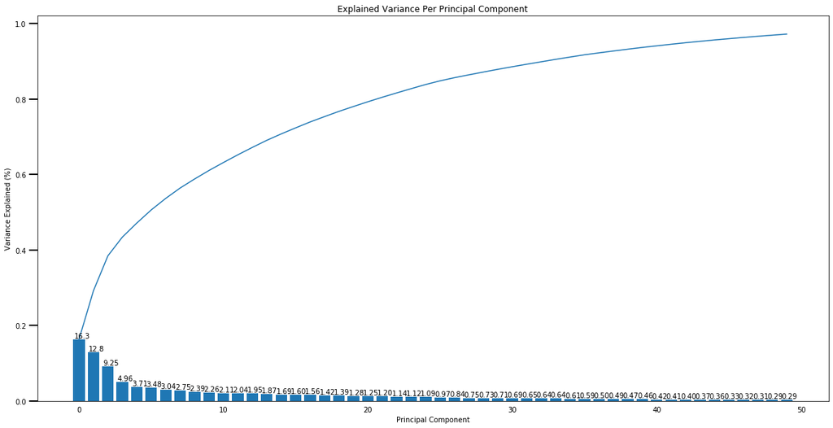

```python
# Re-apply PCA to the data while selecting for number of components to retain.

pca = PCA(50)
pca_features = pca.fit_transform(scaled_values)

scree_plot(pca)
```

### Discussion 2.2: Perform Dimensionality Reduction

After applying PCA, looking at the variance explained by each component, I found that 95% of the variability appeared in the first 50 components, thus, I decided to select only the top 50 components.

### Step 2.3: Interpret Principal Components

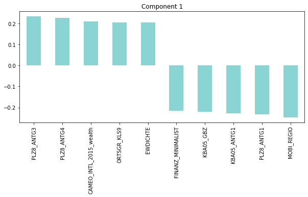

```python
# Map weights for the first principal component to corresponding feature names
# and then print the linked values, sorted by weight.
# HINT: Try defining a function here or in a new cell that you can reuse in the
# other cells.

def pca_results(data, pca, n_components):

    compo = pd.DataFrame(np.round(pca.components_, 4), columns = data.keys()).iloc[n_components-1]
    compo.sort_values(ascending=False, inplace=True)
    compo = pd.concat([compo.head(5), compo.tail(5)])

    compo.plot(figsize=(10,4), kind='bar', title='Component ' + str(n_components), color='#8ad4d4')
    ax = plt.gca()
    ax.set_axisbelow(True)
    plt.show()


pca_results(azdias, pca, 1)
```

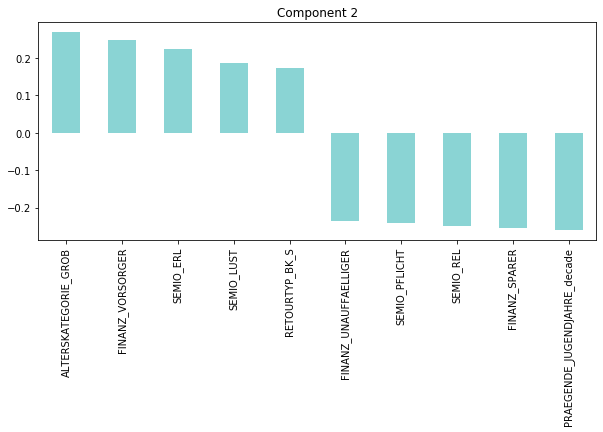

```python
# Map weights for the second principal component to corresponding feature names
# and then print the linked values, sorted by weight.

pca_results(azdias, pca, 2)
```

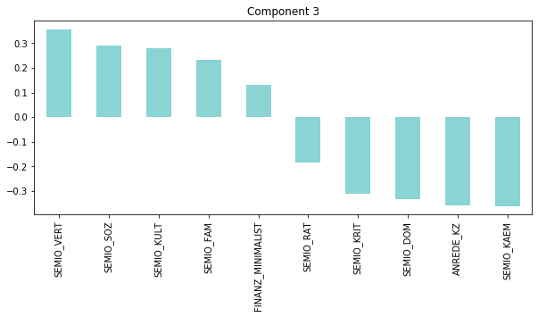

```python
# Map weights for the third principal component to corresponding feature names
# and then print the linked values, sorted by weight.
pca_results(azdias, pca, 3)
```

### Discussion 2.3: Interpret Principal Components

Component 1:

Negative:

1. KBA05_GBZ (Number of buildings in the microcell)
2. KBA05_ANTG1 (Number of 1-2 family houses in the microcell)
3. PLZ8_ANTG1 (Number of 1-2 family houses in the PLZ8 region)
4. MOBI_REGIO (Movement patterns)
5. FINANZ_MINIMALIST (Financial typology)

From the graph, we can conclude that component 1 is correlated with the wealth and financial status of a household, in addition to size of house and family number. From the graph, we can also assume that component 1 has negative correlations with financial saving habits.

Component 2:

Positive:

1. ALTERSKATEGORIE_GROB (Estimated age based on given name analysis)
2. FINANZ_VORSORGER (Financial typology)
3. SEMIO_ERL (Personality typology)
4. SEMIO_LUST (Personality typology)
5. RETOURTYP_BK_S (Return type)

Negative:

1. SEMIO_PFLICHT (Personality typology)
2. FINANZ_UNAUFFAELLIGER (Financial typology)
3. FINANZ_SPARER (Financial typology)
4. SEMIO_REL (Personality typology)
5. PRAEGENDE_JUGENDJAHRE_decade (Dominating decade of person's youth)

For component 2, we can see that age, personality traite and and financial behaviors are correlated with Component 2, as it seems that financial behaviors such as purchase return type and financial prevention behaviors has a positive relation with our component.

Component 3:

For component 3, we can see that personality traits has a big influence on component 3, as it appears on both positive and negative side of the graph.

## Step 3: Clustering

### Step 3.1: Apply Clustering to General Population

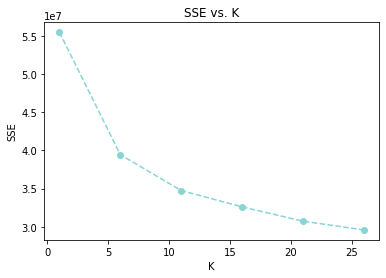

```python
# Over a number of different cluster counts...
# run k-means clustering on the data and...
# compute the average within-cluster distances.

from sklearn.cluster import KMeans

def get_kmeans_score(data, center):
    #instantiate kmeans
    kmeans = KMeans(n_clusters=center)

    # Then fit the model to your data using the fit method
    model = kmeans.fit(data)

    # Obtain a score related to the model fit
    score = np.abs(model.score(data))

    return score

scores = []
centers = list(range(1,30, 5))

for center in centers:
    scores.append(get_kmeans_score(pca_features, center))

plt.plot(centers, scores, linestyle='--', marker='o', color='#8ad4d4');
plt.xlabel('K');
plt.ylabel('SSE');
plt.title('SSE vs. K');
```

```python
# Re-fit the k-means model with the selected number of clusters and obtain
# cluster predictions for the general population demographics data.

kmeans = KMeans(n_clusters = 20)

kmeans_labels_20 = kmeans.fit(pca_features)

azdias_pred = kmeans_labels_20.predict(pca_features)
```

### Discussion 3.1: Apply Clustering to General Population

The method that was used is the elbow method, however it appears that there is no clear elbow, so I decided to go with 20 clusters as that were it seemed to decrease endlessly.

### Step 3.2: Apply All Steps to the Customer Data

```python
# Load in the customer demographics data.
customers = pd.read_csv('Udacity_CUSTOMERS_Subset.csv')
customers = customers.loc[:, ~customers.columns.str.contains('^Unnamed')]
customers_clean = clean_data(customers)
```

```
Binary Categorical Features
['ANREDE_KZ', 'GREEN_AVANTGARDE', 'SOHO_KZ', 'VERS_TYP', 'OST_WEST_KZ']
Count:  5
Multi Categorical Features
['CJT_GESAMTTYP', 'FINANZTYP', 'GFK_URLAUBERTYP', 'LP_FAMILIE_FEIN', 'LP_FAMILIE_GROB', 'LP_STATUS_FEIN', 'LP_STATUS_GROB', 'NATIONALITAET_KZ', 'SHOPPER_TYP', 'ZABEOTYP', 'GEBAEUDETYP', 'CAMEO_DEUG_2015', 'CAMEO_DEU_2015']
Count:  13
W    130382
O     11343
Name: OST_WEST_KZ, dtype: int64
1.0    130382
0.0     11343
Name: OST_WEST_KZ, dtype: int64
```

```python
# Apply preprocessing, feature transformation, and clustering from the general
# demographics onto the customer data, obtaining cluster predictions for the
# customer demographics data.

customers_features_set = customers_clean.copy()

imputer = Imputer(strategy='median')

customers_features_set = imputer.fit_transform(customers_features_set)

scaled_values = scaler.transform(customers_features_set)

customer_clean_scale = pd.DataFrame(scaled_values, columns=customers_clean.columns)

pca_features = pca.transform(scaled_values)

kmeans_customers = kmeans.predict(pca_features)

customers_pred = kmeans_customers
```

### Step 3.3: Compare Customer Data to Demographics Data

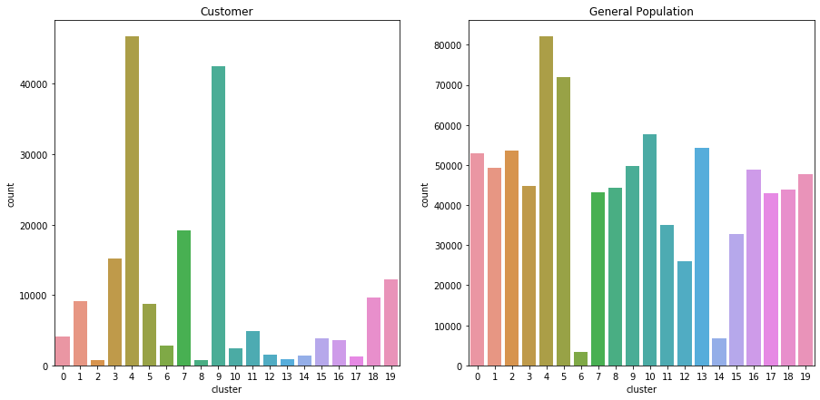

```python
# Compare the proportion of data in each cluster for the customer data to the
# proportion of data in each cluster for the general population.

plt.figure(figsize=(15,7))

plt.subplot(121)
sns.countplot(customers_pred)
plt.xlabel('cluster')
plt.title('Customer')
plt.subplot(122)
sns.countplot(azdias_pred)
plt.xlabel('cluster')
plt.title('General Population')
```

```python
# What kinds of people are part of a cluster that is overrepresented in the
# customer data compared to the general population?

center_1 = scaler.inverse_transform(pca.inverse_transform(kmeans_labels_20.cluster_centers_[1]))
overrepresented = pd.Series(data = center_1, index = customers_cleaning.columns)
overrepresented.head(3)
```

```
ALTERSKATEGORIE_GROB    3.455368
ANREDE_KZ               1.001565
FINANZ_MINIMALIST       3.349947
dtype: float64
```

```python
# What kinds of people are part of a cluster that is underrepresented in the
# customer data compared to the general population?

center_8 = scaler.inverse_transform(pca.inverse_transform(kmeans_labels_20.cluster_centers_[8]))
underrepresented = pd.Series(data = center_8, index = customers_cleaning.columns)
underrepresented.head(3)
```

```
ALTERSKATEGORIE_GROB    1.774001
ANREDE_KZ               1.959443
FINANZ_MINIMALIST       1.109922
dtype: float64
```